# Homework 4: Text Classification with LLMs

Philipp Masur

# Formalities

- Name: [Daniel Commerford]
- Student ID: [2861501]

In the end, klick on “knit” and upload the respective html-output file to Canvas. Please add your name and lastname to the output file name: e.g., 04_homework_assignment_NAME-LASTNAME.html

# Introduction

In this homework, you are going to revisit some of the approaches we have learned throughout the lecture and compare results. We will engage in a simple dictionary analysis, train an algorithm, but also investigate the abilities of zero-shot learning. It is our hope that through this homework, you repeat and deepen all the necessary skills that you need to apply during the project-phase of the course.

# Preparation

In this tutorial, we are going to investigate the sentiment (positive, neutral, negative) of tweets related to COVID-19 in 2020. The tweets have been pulled from Twitter and manual tagging has been done for sentiment. It is a very small data set (n = 80), to not overwhelm the API or the local model.

```r
library(tidyverse)
library(tidytext)
library(tidyllm)
library(glue)
library(yardstick)


# ChatGPT:

Sys.setenv(OPENAI_API_KEY = "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")
```

## Loading data

```r
data <- read_csv("corona_tweets_2020.csv")

# Since tweets still contain quite a bit of unhelpful text:

data <- read_csv("corona_tweets_2020.csv") |>
  filter(!is.na(text) & text != "") |>
  mutate(
    text = str_squish(text),  # Remove extra whitespace
    text = str_replace_all(text, "[\r\n]", " "),  # Replace newlines
    text = str_remove_all(text, "https?://\\S+"),  # Remove URLs entirely
    text = str_remove_all(text, "[#@]")  # Remove hashtags and @ mentions
  ) |>
  rename(sentiment = label)  # Rename 'label' to 'sentiment'


data |> # View finished data
  head()
```

```
## # A tibble: 6 × 6
##   doc_id autor_id location         date       text                     sentiment
##    <dbl>    <dbl> <chr>            <chr>      <chr>                    <chr>
## 1  18030    62982 British Columbia 21-03-2020 "Thank you to all the W… positive
## 2  16709    61661 Topeka, KS       21-03-2020 "Me telling my grandson… neutral
## 3  15236    60188 Canning Town     20-03-2020 "If there was a God thi… negative
## 4  27009    71961 <NA>             25-03-2020 "eternallymist Was hone… negative
## 5   8414    53366 India            18-03-2020 "Sharing for those illi… negative
## 6  27507    72459 Caledon, Ontario 26-03-2020 "Did you have questions… neutral
```

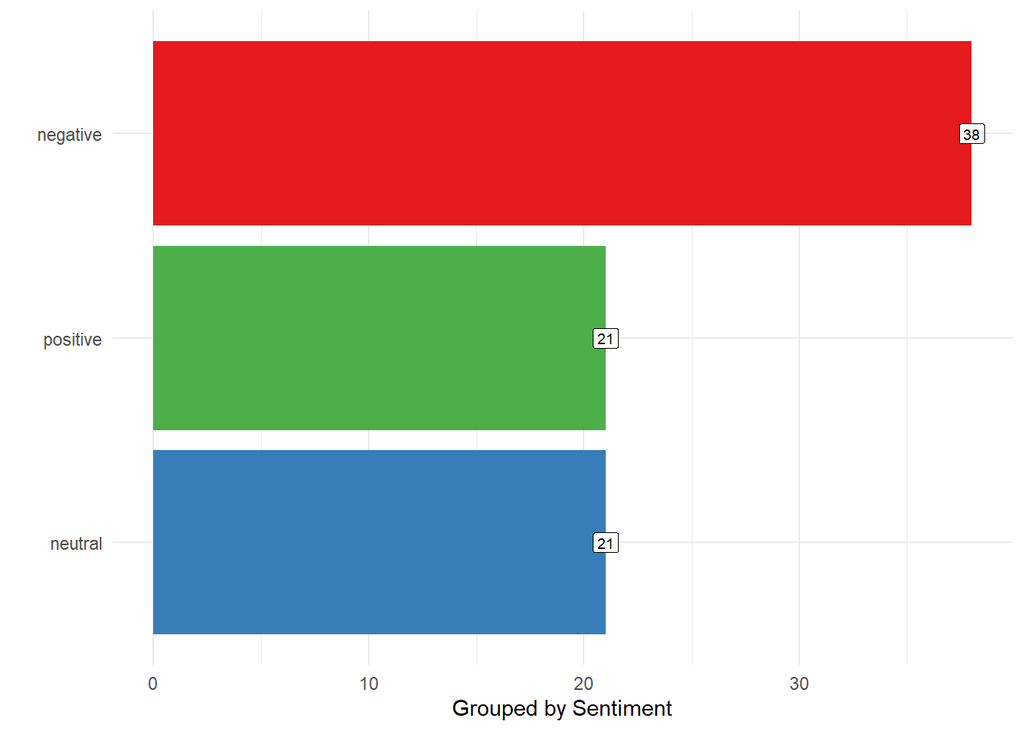

```r
# use ggplot to make a bar chart where the tally can be seen for 'grouped by sentiment'
data |>
  group_by(sentiment) |>
  tally() |>
  filter(sentiment != "unknown") |>
  slice_max(n, n = 25) |>
  ggplot(aes(x = fct_reorder(sentiment, n), y = n, fill = sentiment)) +
  geom_col() +
  geom_label(aes(label = n), fill = "white", size = 2.5) +
  coord_flip() +
  labs(x = "", y = "Grouped by Sentiment") +
  scale_fill_manual(values = c(
    "positive" = "#4daf4a",
    "negative" = "#e41a1c",
    "neutral" = "#377eb8"
  )) +
  theme_minimal() +
  theme(legend.position = "none")
```

#Tasks

## Zero-Shot Classification

Use either ollama (if you have a local model) or GPT-3.5 (don’t forget to set the API token) to classify the tweets using a zero-shot approach. How does the model perform?

```r
#### Solution ####

# Create codebook with glue for each text
codebook <- glue("What is the sentiment in this tweet: {description}

        Pick only one of the following codes from this list:

        Positive, Neutral, or Negative.

        Structure your answer in this way:

                  'Sentiment; Justification'",
                  description = data$text[1:80])


# Create a list of llm-message prompts
classification_task <- map(codebook, llm_message)

# Function to classify all 80 texts
classify_sequential_gpt <- function(texts, message) {
    # Get the raw reply from GPT
    raw_code <- message |>
        chat(openai(.model = "gpt-3.5-turbo", .temperature = .0)) |>
        get_reply()

    # Create a tibble
    tibble(text = texts, label = raw_code)
}


# Run the classification by sequentially prompting GPT
results_gpt <- tibble(texts = data[1:80,]$text,
                      message = classification_task) |>
  pmap_dfr(classify_sequential_gpt, .progress = T)

results_gpt |>
  head()
```

```
## # A tibble: 6 × 2
##   text                                                                     label
##   <chr>                                                                    <chr>
## 1 "Thank you to all the WomenPeacebuilders who are once again responding … "Neu…
## 2 "Me telling my grandson about the great toilet paper shortage and panic… "Neu…
## 3 "If there was a God this virus would target all the twats hoarding and … "Neg…
## 4 "eternallymist Was honestly expecting to be told Ginny died of covid-19… "Neg…
## 5 "Sharing for those illiterates who are commenting without having minimu… "Neg…
## 6 "Did you have questions and concerns after the news that an employee at… "Neu…
```

```r
# Combine them
predict_gpt <- results_gpt |>
  separate(label, c("label", "justification"), sep = ";") |>
  mutate(
    label = tolower(trimws(label)),  # Convert to lowercase and trim whitespace
    label = str_remove(label, "^sentiment:\\s*")  # Remove "sentiment:" prefix if present
  )

# Justifications
head(predict_gpt) |>
  select(label, justification) |>
  head(n = 6)
```

```
## # A tibble: 6 × 2
##   label    justification
##   <chr>    <chr>
## 1 neutral  " The tweet expresses gratitude and support towards WomenPeacebuilde…
## 2 neutral  " The tweet is simply stating a fact about the past toilet paper sho…
## 3 negative " The tweet expresses frustration and anger towards individuals who …
## 4 negative " The tweet expresses a negative sentiment by mentioning a dark and …
## 5 negative " The tweet uses derogatory language (\"illiterates\") and implies t…
## 6 neutral  " The tweet is informative and seeks to address questions and concer…
```

```r
#### Validation ####

predict_gpt <- predict_gpt |>
  select(label) |>
  bind_cols(data[1:80,]) |>
  mutate(label = factor(label, levels = c("positive", "neutral", "negative")),
      sentiment = factor(sentiment, levels = c("positive", "neutral", "negative")))

# performance scores
class_metrics <- metric_set(accuracy, precision, recall, f_meas)

predict_gpt |>
  class_metrics(truth = sentiment, estimate = label)
```

```
## # A tibble: 4 × 3
##   .metric   .estimator .estimate
##   <chr>     <chr>          <dbl>
## 1 accuracy  multiclass     0.591
## 2 precision macro          0.724
## 3 recall    macro          0.552
## 4 f_meas    macro          0.482
```

## One-Shot Classification

Can you improve the performance with a one-shot approach? How did the model perform now?

```r
# Solution

oneshotattempt <- llm_message(glue("What is the sentiment in this tweet: {description}",
                   description = data$text[1])) |>
  llm_message("positive", .role = "assistant")

# Similar process
classification_tasks <- glue("Now the sentiment of the following tweet in the same way: {description}

                             Pick only one of the following codes from this list.
                             Only provide the code, nothing else.

                             Positive, Neutral, or Negative",
                   description = data$text[2:80])

# Map the tasks together

# Use oneshotattempt as the initial context after it gave initial error
oneshot_tasks <- map(classification_tasks, function(x) {
    oneshotattempt |> llm_message(x)
})

# Check if it worked:
oneshot_tasks[[1]]
```

```
## Message History:
## system: You are a helpful assistant
## --------------------------------------------------------------
## user: What is the sentiment in this tweet: Thank you to all the WomenPeacebuilders who are once again responding to the needs of your communities dealing In reality you are the first responders in the community. Please know you are not alone. whatthewomensay sanambna Yemen pakistan Uganda
## --------------------------------------------------------------
## assistant: positive
## --------------------------------------------------------------
## user: Now the sentiment of the following tweet in the same way: Me telling my grandson about the great toilet paper shortage and panic of 2020 . . . . . thiscantbelife compositionbookchronicles cqcomics toiletpaper toiletpapercrisis 2020 coronavirus covid_19
##
## Pick only one of the following codes from this list.
## Only provide the code, nothing else.
##
## Positive, Neutral, or Negative
## --------------------------------------------------------------
```

```r
# Function used to classify all tweets using GPT
classify_sequential_gpt <- function(texts, message){
    raw_code <- message |>
        chat(openai(.model = "gpt-3.5-turbo",
                    .temperature = .0)) |>
        get_reply()
    tibble(text = texts, label = raw_code)
}

# Run classifications
results_gpt_oneshot <- tibble(texts = data[2:80,]$text,
                              message = oneshot_tasks) |>
  pmap_dfr(classify_sequential_gpt, .progress = T)

# See if it worked, compare to gold standard in the same way as Zero Shot:
predict_gpt_oneshot <- results_gpt_oneshot  |>
  select(label) |>
  mutate(label = tolower(label)) |>
  bind_cols(data[2:80,]) |>
  mutate(label = factor(label, levels = c("positive", "neutral", "negative")),
      sentiment = factor(sentiment, levels = c("positive", "neutral", "negative")))

# display tibble of results:
head(predict_gpt_oneshot)
```

```
## # A tibble: 6 × 7
##   label    doc_id autor_id location          date       text           sentiment
##   <fct>     <dbl>    <dbl> <chr>             <chr>      <chr>          <fct>
## 1 neutral   16709    61661 Topeka, KS        21-03-2020 "Me telling m… neutral
## 2 negative  15236    60188 Canning Town      20-03-2020 "If there was… negative
## 3 negative  27009    71961 <NA>              25-03-2020 "eternallymis… negative
## 4 neutral    8414    53366 India             18-03-2020 "Sharing for … negative
## 5 neutral   27507    72459 Caledon, Ontario  26-03-2020 "Did you have… neutral
## 6 neutral   16564    61516 Trinidad & Tobago 21-03-2020 "The Oppositi… neutral
```

```r
# Check quality metrics of the one shot example:
predict_gpt_oneshot |>
  class_metrics(truth = sentiment, estimate = label)
```

```
## # A tibble: 4 × 3
##   .metric   .estimator .estimate
##   <chr>     <chr>          <dbl>
## 1 accuracy  multiclass     0.734
## 2 precision macro          0.711
## 3 recall    macro          0.720
## 4 f_meas    macro          0.715
```

## Few-Shot Classification

Can you improve the performance with a few-shot approach? How did the model perform now?

```r
# Make variable and stack llm_messages

fewshotattempt <-
  llm_message(glue("What is the overall sentiment of this tweet: {description}",
                   description = data$text[1])) |>
  llm_message("positive", .role = "assistant") |>
  llm_message(glue("What is the overall sentiment of this tweet: {description}",
                   description = data$text[2])) |>
  llm_message("negative", .role = "assistant") |>
  llm_message(glue("What is the overall sentiment of this tweet: {description}",
                   description = data$text[3])) |>
  llm_message("neutral", .role = "assistant")

# Do the classification task

classification_tasks <- glue("Now classify the following tweet in the same way: {description}

                             Pick only one of the following codes from this list.
                             Only provide the code, nothing else.

                             Positive, Neutral, or Negative",
                             description = data$text[4:80]) # number set to number after # of examples given

# Map the tasks together
fewshot_tasks <- map(classification_tasks, function(x) fewshotattempt |> llm_message(x))

# Check
fewshot_tasks[[1]]
```

```
## Message History:
## system: You are a helpful assistant
## --------------------------------------------------------------
## user: What is the overall sentiment of this tweet: Thank you to all the WomenPeacebuilders who are once again responding to the needs of your communities dealing In reality you are the first responders in the community. Please know you are not alone. whatthewomensay sanambna Yemen pakistan Uganda
## --------------------------------------------------------------
## assistant: positive
## --------------------------------------------------------------
## user: What is the overall sentiment of this tweet: Me telling my grandson about the great toilet paper shortage and panic of 2020 . . . . . thiscantbelife compositionbookchronicles cqcomics toiletpaper toiletpapercrisis 2020 coronavirus covid_19
## --------------------------------------------------------------
## assistant: negative
## --------------------------------------------------------------
## user: What is the overall sentiment of this tweet: If there was a God this virus would target all the twats hoarding and panic buying but unfortunately it seems the twats are winning, tho karma is a bitch coronavirus StopPanicBuying
## --------------------------------------------------------------
## assistant: neutral
## --------------------------------------------------------------
## user: Now classify the following tweet in the same way: eternallymist Was honestly expecting to be told Ginny died of covid-19 while working in a grocery store after Harry lost his job.
##
## Pick only one of the following codes from this list.
## Only provide the code, nothing else.
##
## Positive, Neutral, or Negative
## --------------------------------------------------------------
```

```r
# Function to classify all tweets
classify_sequential_gpt <- function(texts, message){
    raw_code <- message |>
        chat(openai(.model = "gpt-3.5-turbo",
                    .temperature = .0)) |>
        get_reply()
    tibble(text = texts, label = raw_code)
}

# Run classifications
results_gpt_fewshot <- tibble(texts = data[4:80,]$text,
                              message = fewshot_tasks) |>
  pmap_dfr(classify_sequential_gpt, .progress = T)

# Bin prediction to gold standard
predict_gpt_fewshot <- results_gpt_fewshot  |>
  select(label) |>
  mutate(label = tolower(label)) |>
  bind_cols(data[4:80,]) |>
  mutate(label = factor(label, levels = c("positive", "neutral", "negative")),
      sentiment = factor(sentiment, levels = c("positive", "neutral", "negative")))

head(predict_gpt_fewshot)
```

```
## # A tibble: 6 × 7
##   label    doc_id autor_id location          date       text           sentiment
##   <fct>     <dbl>    <dbl> <chr>             <chr>      <chr>          <fct>
## 1 negative  27009    71961 <NA>              25-03-2020 "eternallymis… negative
## 2 neutral    8414    53366 India             18-03-2020 "Sharing for … negative
## 3 neutral   27507    72459 Caledon, Ontario  26-03-2020 "Did you have… neutral
## 4 neutral   16564    61516 Trinidad & Tobago 21-03-2020 "The Oppositi… neutral
## 5 positive  26521    71473 <NA>              25-03-2020 "Please all g… positive
## 6 neutral    5951    50903 The Colony, TX    17-03-2020 "Me: With eve… positive
```

```r
# Check final quality metrics

predict_gpt_fewshot |>
  class_metrics(truth = sentiment, estimate = label)
```

```
## # A tibble: 4 × 3
##   .metric   .estimator .estimate
##   <chr>     <chr>          <dbl>
## 1 accuracy  multiclass     0.636
## 2 precision macro          0.640
## 3 recall    macro          0.648
## 4 f_meas    macro          0.623
```

## Comparison of all three approaches?

Can you plot the performance of all three approaches? WHich performs best?

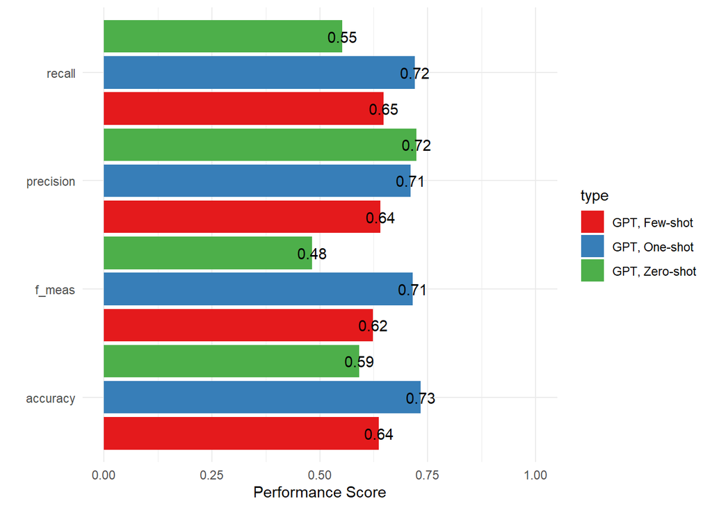

```r
# Solution

# Plot performance of all three approaches
bind_rows(
  predict_gpt |>
  class_metrics(truth = sentiment, estimate = label) |>
  mutate(type = "GPT, Zero-shot"),
  predict_gpt_oneshot |>
  class_metrics(truth = sentiment, estimate = label) |>
  mutate(type = "GPT, One-shot"),
  predict_gpt_fewshot |>
  class_metrics(truth = sentiment, estimate = label) |>
  mutate(type = "GPT, Few-shot")
) |>
  ggplot(aes(x = .metric, y = .estimate, fill = type)) +
  geom_col(position = position_dodge(width = 1)) +
  geom_text(aes(label = round(.estimate, 2)), position = position_dodge(width = 1)) +
  coord_flip() +
  scale_fill_brewer(palette = "Set1") +
  ylim(0, 1) +
  theme_minimal() +
  labs(x = "", y = "Performance Score")
```

**Answer:** The general observation is that the one-shot classification method was the most successful overall. It yielded the highest results, but the performance across all three methods was moderate at best. In terms of accuracy, it can range from a little better than guessing to having an accuracy of three-fourths.